# BF_HW_ARIMA

sp2245@scarletmail.rutgers.edu

11/10/2022

```r
library(fpp)
library(fpp2)
```

```r
library(forecast)

## Data set- fdeaths
#### fdeaths plot
fdeaths
```

```
##       Jan  Feb  Mar  Apr  May  Jun  Jul  Aug  Sep  Oct  Nov  Dec
## 1974  901  689  827  677  522  406  441  393  387  582  578  666
## 1975  830  752  785  664  467  438  421  412  343  440  531  771
## 1976  767 1141  896  532  447  420  376  330  357  445  546  764
## 1977  862  660  663  643  502  392  411  348  387  385  411  638
## 1978  796  853  737  546  530  446  431  362  387  430  425  679
## 1979  821  785  727  612  478  429  405  379  393  411  487  574
```

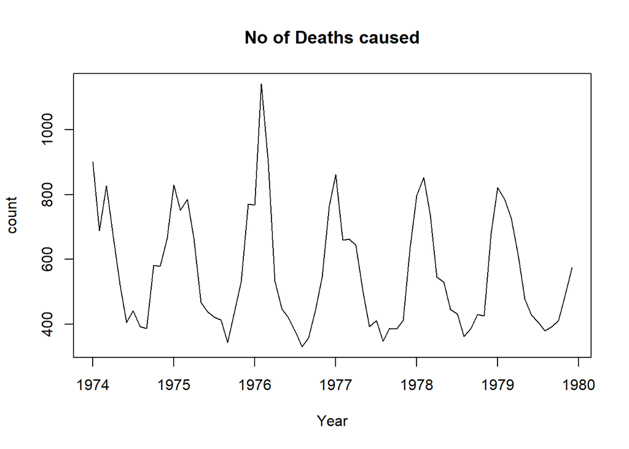

```r
plot(fdeaths, main = 'No of Deaths caused', xlab = 'Year', ylab = 'count')
```

- We can observe that the data has seasonality.

### Window plot

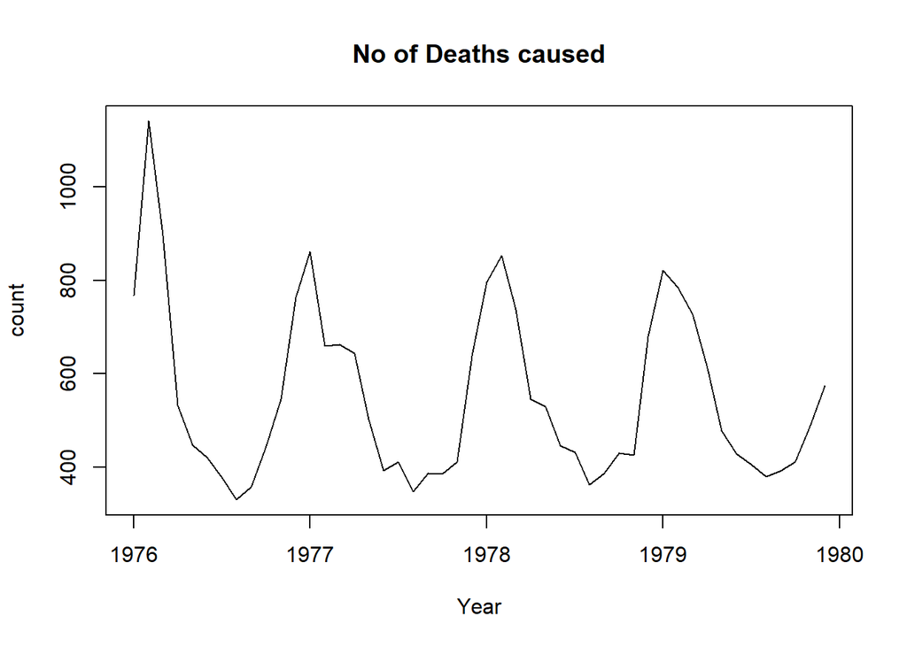

```r
deaths_win <- window(fdeaths, start = 1976)
plot(deaths_win, main = 'No of Deaths caused', xlab = 'Year', ylab = 'count')
```

- We can observe that after applying windows fucntion and taking a window from 1976 to the data, we still see seasonality in the data.

#### Acf plot

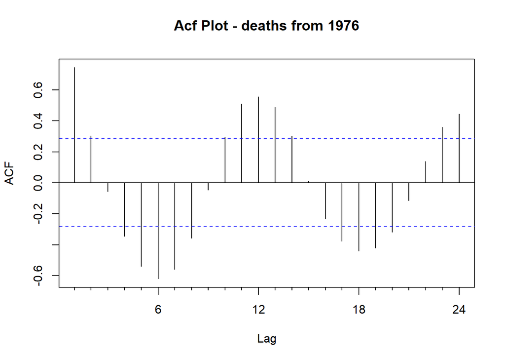

```r
Acf(deaths_win, main = 'Acf Plot - deaths from 1976')
```

*We see seasonality after using the Acf function as well.

## ARIMA for data with seasonal component

#### Checking the Differencing needed for seasonal component

nsdiffs(deaths_win) # nsdiffs is for seasonal

#nsdiffs is use to know how many differences we need to do for seasonality component.

#### Checking the Differences needed

ndiffs(deaths_win) # We got the ndiffs as 0

#### Rechecking the differencing needed after performing the seasonal differencing.

ndiffs((diff(deaths_win,12))) # The ndiffs still shows as 0.

#### Acf and Pacf plots

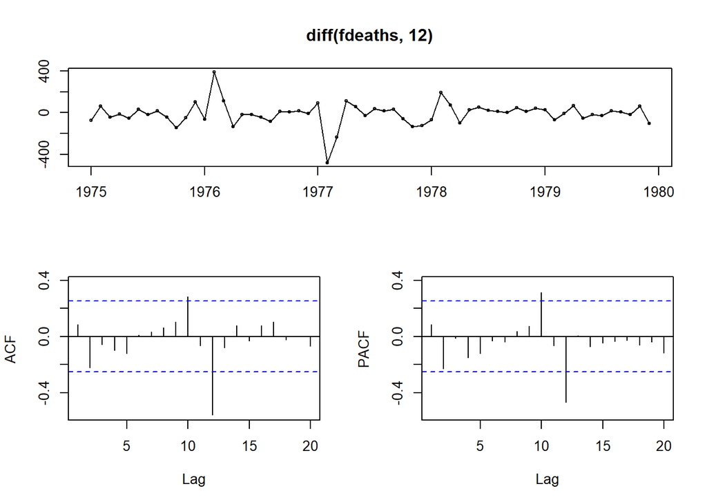

```r
tsdisplay(diff(fdeaths,12))
```

* In the Acf plot we can see that the p value is 2.

#### Arima Model

```r
arima_fit <- auto.arima(deaths_win,trace=TRUE, stepwise = FALSE )
```

```
##
##  ARIMA(0,0,0)(0,1,0)[12]                    : 443.4498
##  ARIMA(0,0,0)(0,1,0)[12] with drift         : 445.0823
##  ARIMA(0,0,0)(0,1,1)[12]                    : Inf
##  ARIMA(0,0,0)(0,1,1)[12] with drift         : Inf
##  ARIMA(0,0,0)(1,1,0)[12]                    : 432.3984
##  ARIMA(0,0,0)(1,1,0)[12] with drift         : 434.2961
##  ARIMA(0,0,0)(1,1,1)[12]                    : 432.7884
##  ARIMA(0,0,0)(1,1,1)[12] with drift         : 434.4438
##  ARIMA(0,0,1)(0,1,0)[12]                    : 440.698
##  ARIMA(0,0,1)(0,1,0)[12] with drift         : 442.9866
##  ARIMA(0,0,1)(0,1,1)[12]                    : Inf
##  ARIMA(0,0,1)(0,1,1)[12] with drift         : Inf
##  ARIMA(0,0,1)(1,1,0)[12]                    : 429.2622
##  ARIMA(0,0,1)(1,1,0)[12] with drift         : 431.6525
##  ARIMA(0,0,1)(1,1,1)[12]                    : Inf
##  ARIMA(0,0,1)(1,1,1)[12] with drift         : Inf
##  ARIMA(0,0,2)(0,1,0)[12]                    : Inf
##  ARIMA(0,0,2)(0,1,0)[12] with drift         : Inf
##  ARIMA(0,0,2)(0,1,1)[12]                    : Inf
##  ARIMA(0,0,2)(0,1,1)[12] with drift         : Inf
##  ARIMA(0,0,2)(1,1,0)[12]                    : 427.5538
##  ARIMA(0,0,2)(1,1,0)[12] with drift         : 429.8363
##  ARIMA(0,0,2)(1,1,1)[12]                    : Inf
##  ARIMA(0,0,2)(1,1,1)[12] with drift         : Inf
##  ARIMA(0,0,3)(0,1,0)[12]                    : Inf
##  ARIMA(0,0,3)(0,1,0)[12] with drift         : Inf
##  ARIMA(0,0,3)(0,1,1)[12]                    : Inf
##  ARIMA(0,0,3)(0,1,1)[12] with drift         : Inf
##  ARIMA(0,0,3)(1,1,0)[12]                    : Inf
##  ARIMA(0,0,3)(1,1,0)[12] with drift         : Inf
##  ARIMA(0,0,3)(1,1,1)[12]                    : Inf
##  ARIMA(0,0,3)(1,1,1)[12] with drift         : Inf
##  ARIMA(0,0,4)(0,1,0)[12]                    : Inf
##  ARIMA(0,0,4)(0,1,0)[12] with drift         : 440.4229
##  ARIMA(0,0,4)(0,1,1)[12]                    : Inf
##  ARIMA(0,0,4)(0,1,1)[12] with drift         : Inf
##  ARIMA(0,0,4)(1,1,0)[12]                    : Inf
##  ARIMA(0,0,4)(1,1,0)[12] with drift         : Inf
##  ARIMA(0,0,5)(0,1,0)[12]                    : 438.9798
```

[output cut: 72 more lines]

```
##  ARIMA(3,0,2)(0,1,0)[12] with drift         : 442.6489
##  ARIMA(4,0,0)(0,1,0)[12]                    : 439.1524
##  ARIMA(4,0,0)(0,1,0)[12] with drift         : 441.4074
##  ARIMA(4,0,0)(0,1,1)[12]                    : Inf
##  ARIMA(4,0,0)(0,1,1)[12] with drift         : Inf
##  ARIMA(4,0,0)(1,1,0)[12]                    : 428.3643
##  ARIMA(4,0,0)(1,1,0)[12] with drift         : 431.3285
##  ARIMA(4,0,1)(0,1,0)[12]                    : 440.6526
##  ARIMA(4,0,1)(0,1,0)[12] with drift         : 443.1805
##  ARIMA(5,0,0)(0,1,0)[12]                    : 442.0439
##  ARIMA(5,0,0)(0,1,0)[12] with drift         : 444.5072
##
##
##
##  Best model: ARIMA(2,0,1)(1,1,0)[12]
```

```r
arima_fit
```

```
## Series: deaths_win
## ARIMA(2,0,1)(1,1,0)[12]
##
## Coefficients:
##          ar1      ar2      ma1     sar1
##       0.9809  -0.8434  -0.7226  -0.8060
## s.e.  0.1445   0.1408   0.2045   0.0896
##
## sigma^2 = 4181:  log likelihood = -206.36
## AIC=422.71   AICc=424.71   BIC=430.63
```

- The system runs the auto arima and gives out the best model for which the AIC value is the lowest. The AIC value is 422.71 and the ARIMA(2,0,1)(1,1,0)[12].

#### Arima Model attributes

```r
attributes(arima_fit)
```

```
## $names
##  [1] "coef"      "sigma2"    "var.coef"  "mask"      "loglik"    "aic"
##  [7] "arma"      "residuals" "call"      "series"    "code"      "n.cond"
## [13] "nobs"      "model"     "bic"       "aicc"      "x"         "fitted"
##
## $class
## [1] "forecast_ARIMA" "ARIMA"          "Arima"
```

#### Plotting forecast of the Arima model with 99.5% confidence

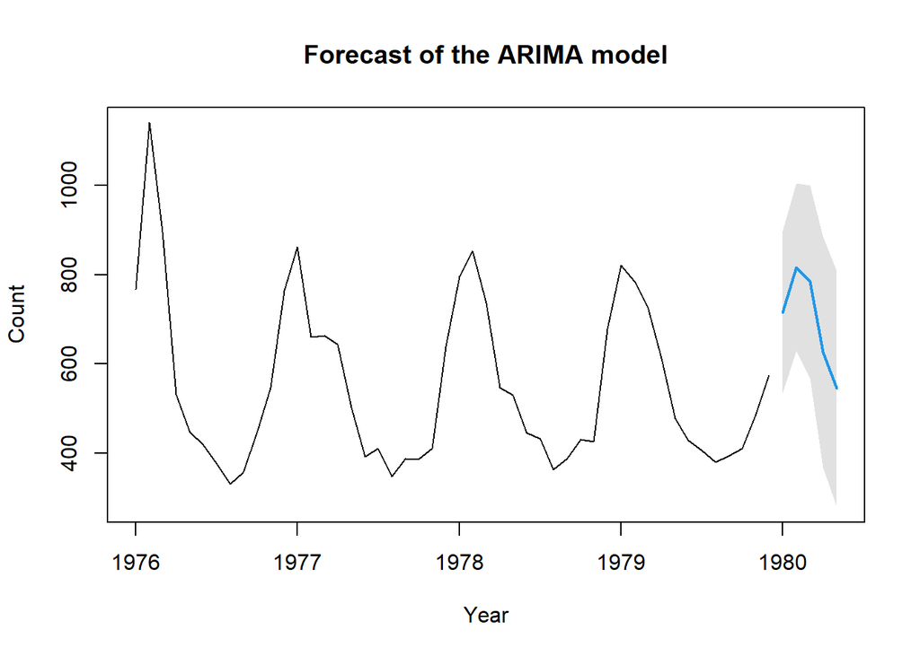

```r
plot(forecast(arima_fit,h=5,level=c(99.5)), main = 'Forecast of the ARIMA model', xlab = 'Year', ylab = 'Count')
```

## Residual Analysis

#### Acf of Residuals

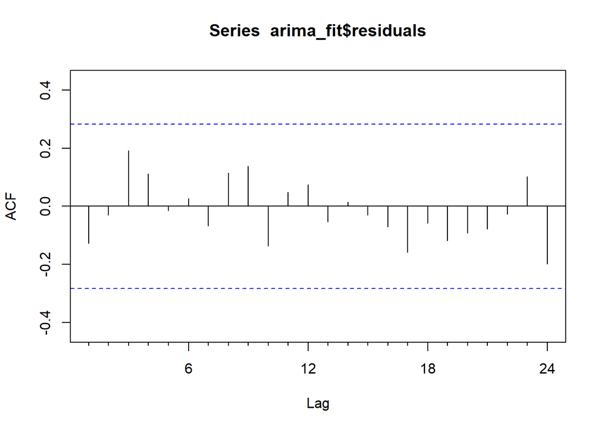

```r
Acf(arima_fit$residuals)
```

* We can observe that none of the data passes the confidence interval limits. * Which means that the forecast is a good forecast.

#### Box-Ljung test

```r
Box.test(residuals(arima_fit), lag=20, type="Ljung")
```

```
##
##  Box-Ljung test
##
## data:  residuals(arima_fit)
## X-squared = 12.232, df = 20, p-value = 0.9079
```

- The p-value is greater than 0.05 ( p value= 0.9079) so we can determine that the null hypothesis is supported.
- The residuals are random.

#### Residuals plot

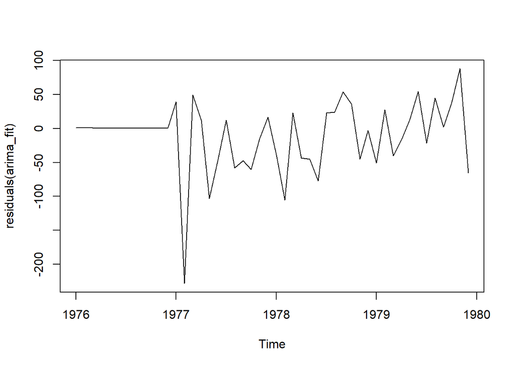

```r
plot.ts(residuals(arima_fit))
```

* The residuals appear to be random adn we can say this is a good forecasting model.

#### Histogram plot of residuals

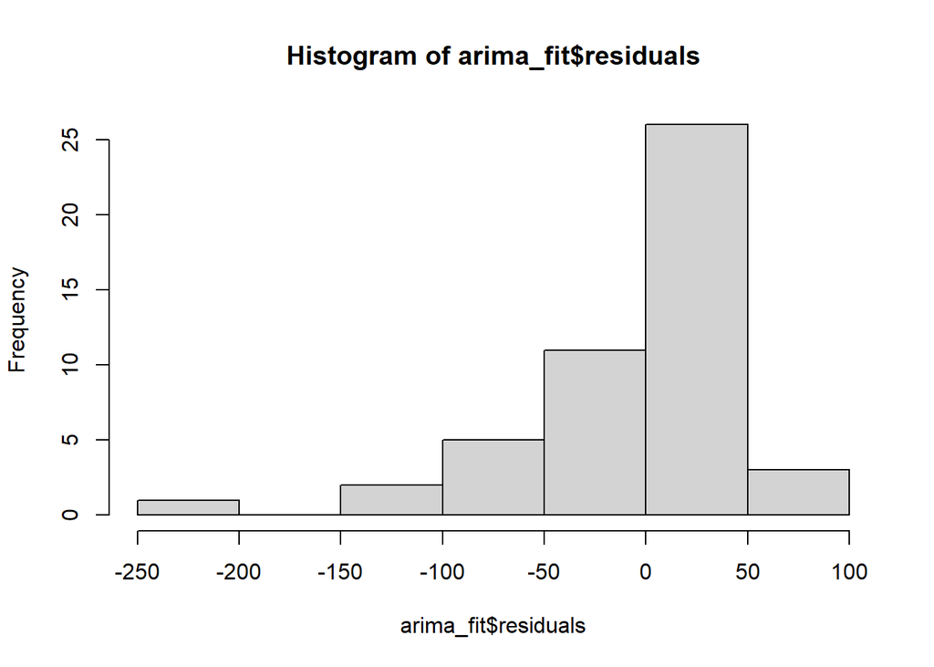

```r
hist(arima_fit$residuals)
```

* We can observe that the distribution is not normally distributed and left skewed as well.

#### TSDiagram of the ARIMA model

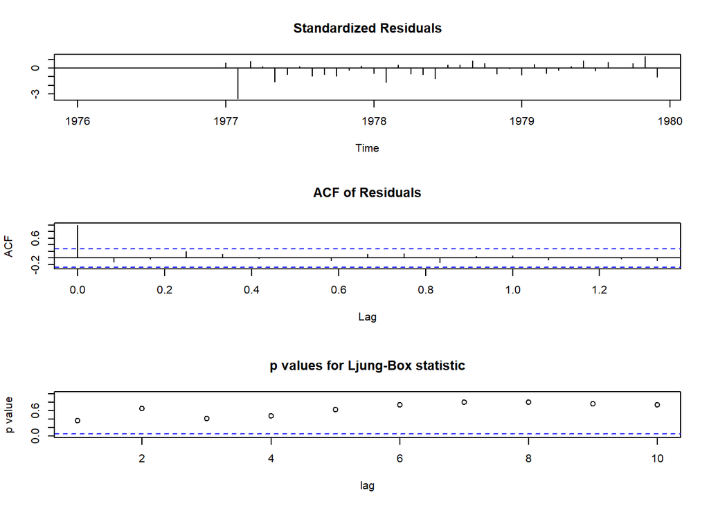

```r
tsdiag(arima_fit)
```

- The standardized residuals plot looks good. We can see 3 residuals are very close to touch.
- There are no significant values in the Acf plot as we see there are no values above the confidence interval.
- The p-values in Ljung-Box test are also above level and the points are above the confidence interval line ( blue line).
- The ARIMA model is a good fit.